# ST404 Assignment 1

jena

We are analysing 4 variables of the Cancer data: Incidence Rate, Percent Married, PctMarriedHouseholds and Edu18_24.

# Load Data and Summary of the Data

```r
load("cancer.RData")
library(dplyr)
library(GGally)
```

```r
library(ggplot2)
library(car)
cancer1 <- cancer
cancer1$AvgHouseholdSize[cancer1$AvgHouseholdSize < 0.5] <- NA
cancer2 <- na.omit(cancer1)
cancer2_select<- select(cancer, incidenceRate, PercentMarried,PctMarriedHouseholds, Edu18_24)
summary(cancer2_select)
```

```
##  incidenceRate    PercentMarried  PctMarriedHouseholds    Edu18_24
##  Min.   : 201.3   Min.   :23.10   Min.   :22.99        Min.   :1.487
##  1st Qu.: 420.3   1st Qu.:47.75   1st Qu.:47.76        1st Qu.:2.206
##  Median : 453.5   Median :52.40   Median :51.67        Median :2.340
##  Mean   : 448.3   Mean   :51.77   Mean   :51.24        Mean   :2.347
##  3rd Qu.: 480.9   3rd Qu.:56.40   3rd Qu.:55.40        3rd Qu.:2.486
##  Max.   :1206.9   Max.   :72.50   Max.   :78.08        Max.   :3.307
```

# Check for missing values

```r
sum(is.na(cancer2_select))
```

```
## [1] 0
```

No missing values found in the variables.

# Univariate Analysis

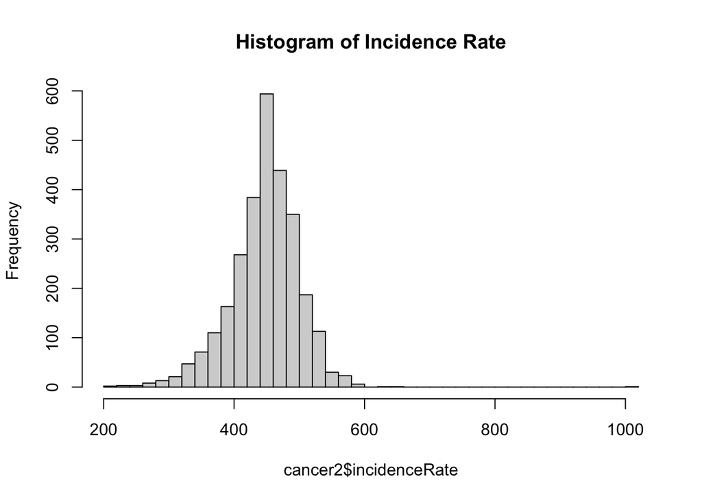

```r
hist(cancer2$incidenceRate, breaks = 30, main = "Histogram of Incidence Rate")
```

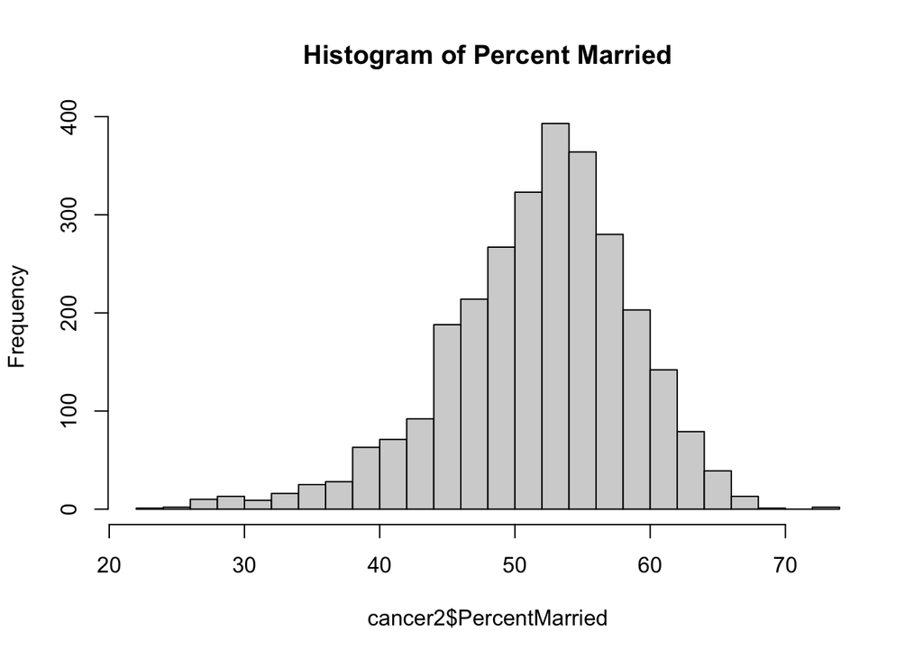

```r
hist(cancer2$PercentMarried, breaks = 30, main = "Histogram of Percent Married")
```

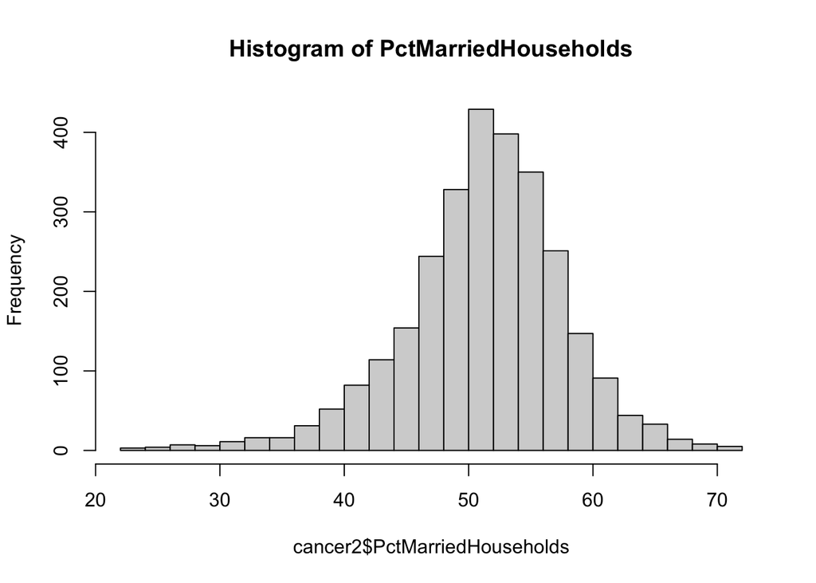

```r
hist(cancer2$PctMarriedHouseholds, breaks = 30, main = "Histogram of PctMarriedHouseholds")
```

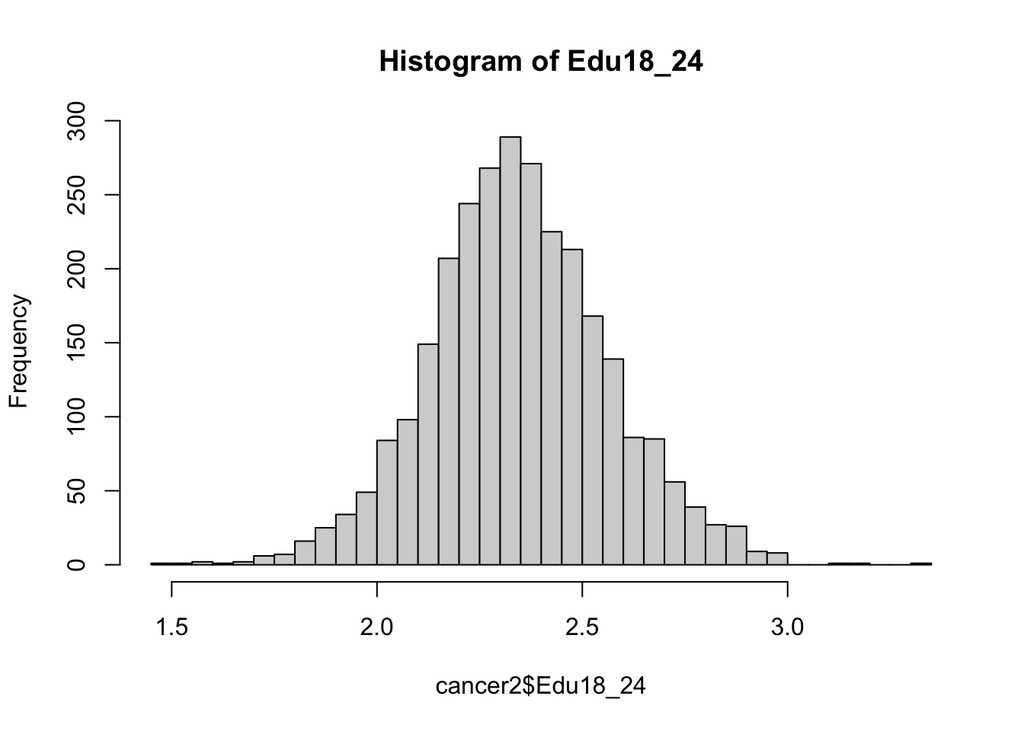

```r
hist(cancer2$Edu18_24, breaks = 30, main = "Histogram of Edu18_24")
```

PercentMarried and PctMarriedHouseholds are also slightly left skewed. We can fix this using square transformation.

# Transformation

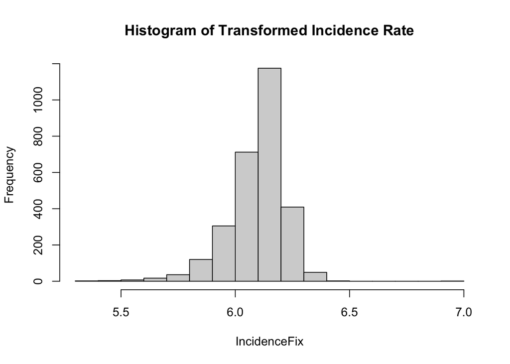

```r
IncidenceFix <- log(cancer2$incidenceRate)
hist(IncidenceFix, main = "Histogram of Transformed Incidence Rate")
```

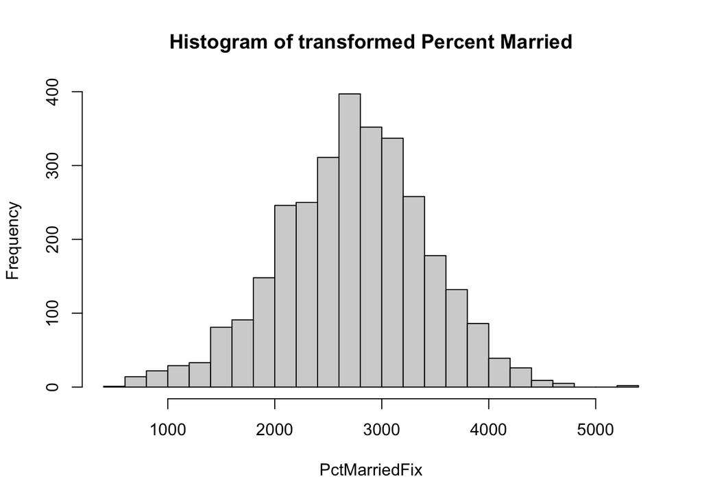

```r
PctMarriedFix<- cancer$PercentMarried^(2)
hist(PctMarriedFix, breaks = 30, main = "Histogram of transformed Percent Married")
```

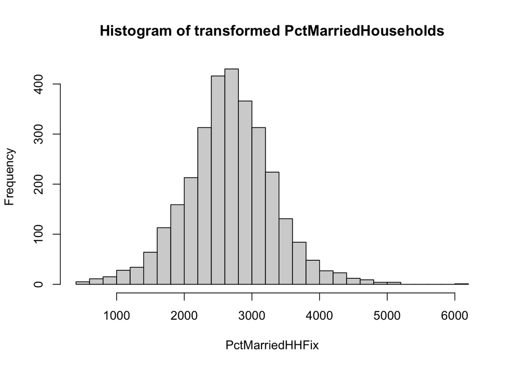

```r
PctMarriedHHFix<- cancer$PctMarriedHouseholds^(2)
hist(PctMarriedHHFix, breaks = 30, main = "Histogram of transformed PctMarriedHouseholds")
```

# Check for Outliers

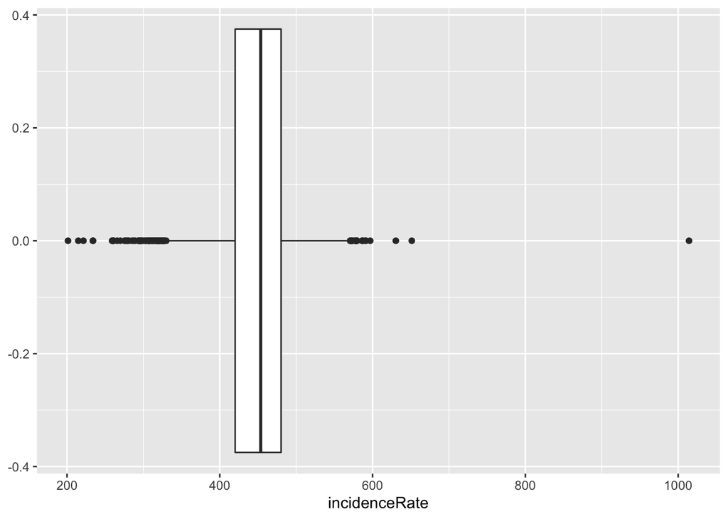

```r
library(ggplot2)
ggplot(cancer2, aes(incidenceRate)) + geom_boxplot()
```

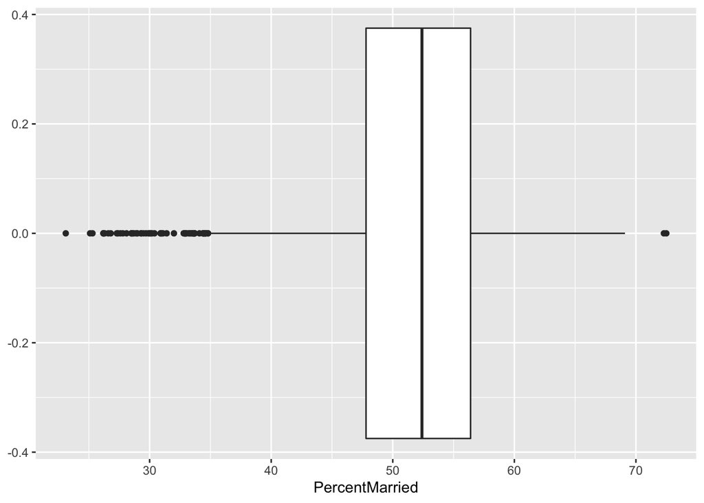

```r
ggplot(cancer2, aes(PercentMarried)) + geom_boxplot()
```

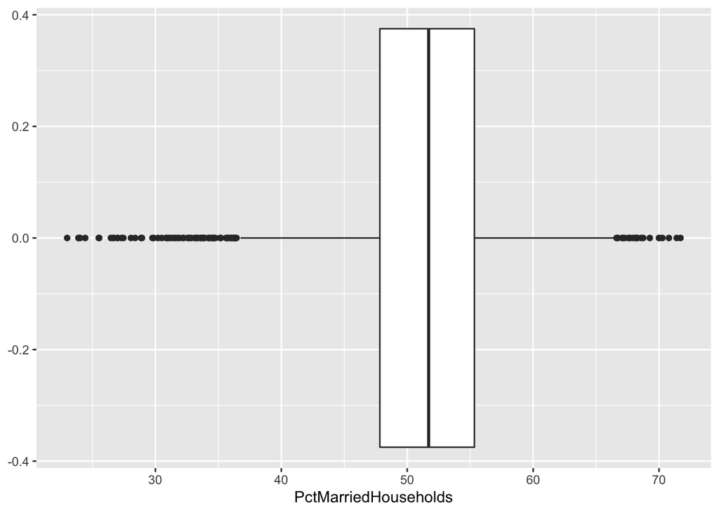

```r
ggplot(cancer2,aes(PctMarriedHouseholds)) + geom_boxplot()
```

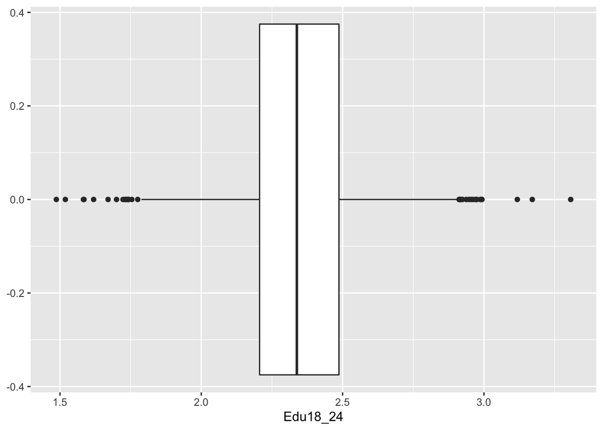

```r
ggplot(cancer2, aes(Edu18_24)) + geom_boxplot()
```

We observe that the outliers are present for all predictor variables.

In particular, the boxplot for Incidence rate shows the existence of extreme high values.

Therefore, we might want to investigate into the outliers of the predictor variables and decide how we might want to treat them before fitting the model.

Possible options might include deleting the outliers or imputing them.

This might depend on whether the outlier is due to some error (data entry, sampling, measurement) or whether the outlier is natural.

# Bivariate Analysis

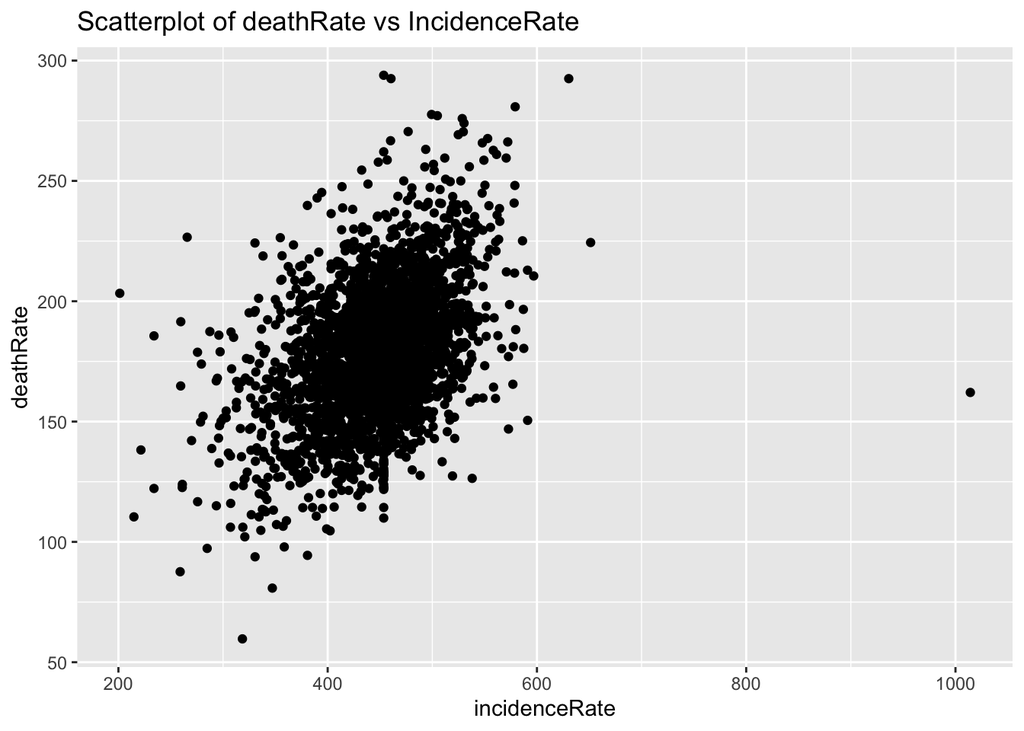

```r
par(mfrow=c(2,2))
ggplot(cancer2, aes(x=incidenceRate,y=deathRate))+
  geom_point()+
  ggtitle("Scatterplot of deathRate vs IncidenceRate")
```

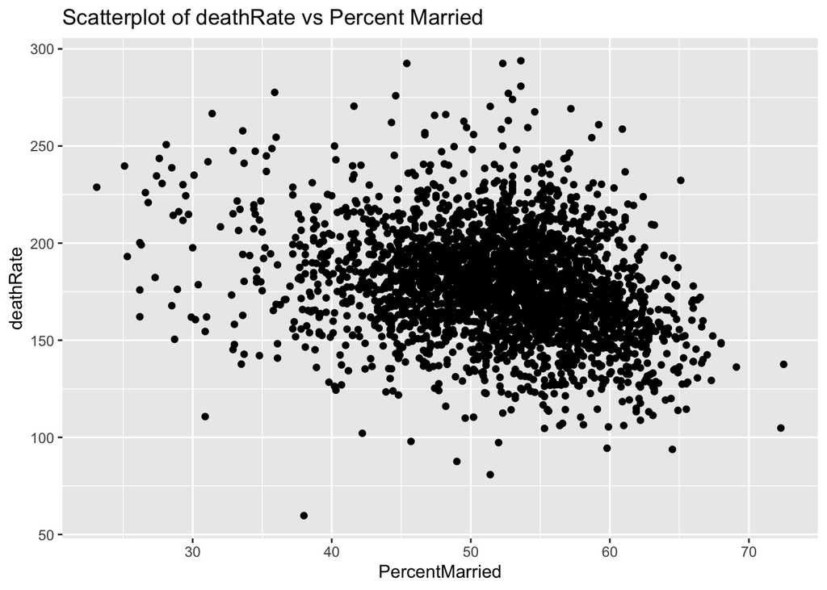

```r
ggplot(cancer2, aes(x=PercentMarried,y=deathRate))+
  geom_point()+
  ggtitle("Scatterplot of deathRate vs Percent Married")
```

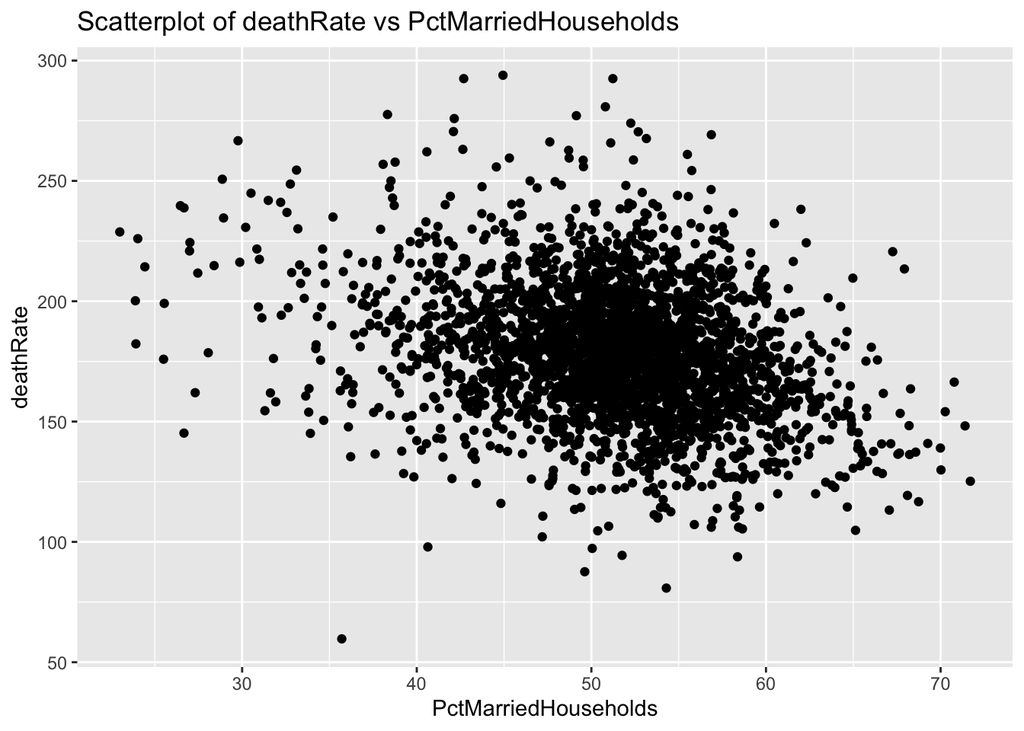

```r
ggplot(cancer2, aes(x=PctMarriedHouseholds,y=deathRate))+
  geom_point()+
  ggtitle("Scatterplot of deathRate vs PctMarriedHouseholds")
```

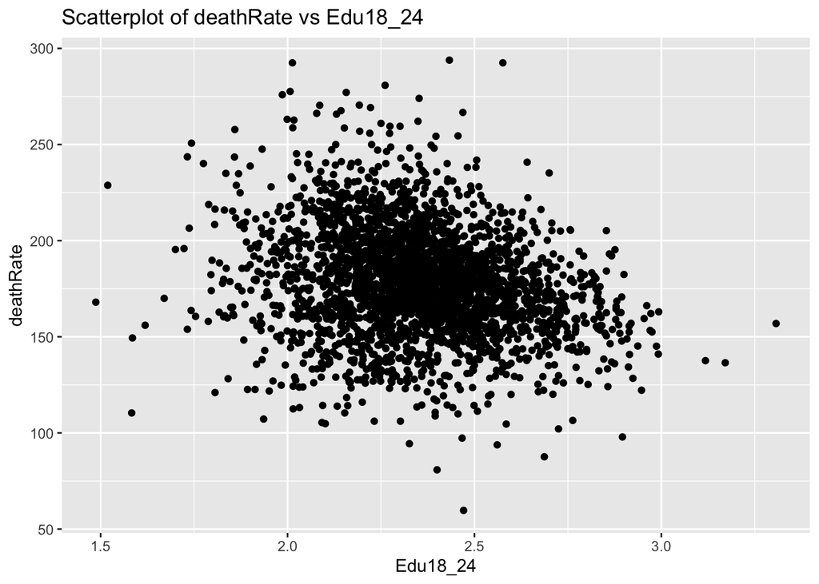

```r
ggplot(cancer2, aes(x=Edu18_24,y=deathRate))+
  geom_point()+
  ggtitle("Scatterplot of deathRate vs Edu18_24")
```

```r
par(mfrow=c(2,2))
scatter.smooth(cancer2$incidenceRate, cancer2$deathRate, lpars=list(col = "blue", lwd = 2), ylab="deathRate",xlab="Incidence Rate")

scatter.smooth(cancer2$PercentMarried, cancer2$deathRate, lpars=list(col = "blue", lwd = 2),
ylab="deathRate", xlab="Percent Married")

scatter.smooth(cancer2$PctMarriedHouseholds, cancer2$deathRate, lpars=list(col = "blue", lwd = 2),
ylab="deathRate",xlab="PctMarriedHouseholds")

scatter.smooth(cancer2$Edu18_24, cancer2$deathRate, lpars=list(col = "blue", lwd = 2),
ylab="deathRate",xlab="Edu18_24")
```

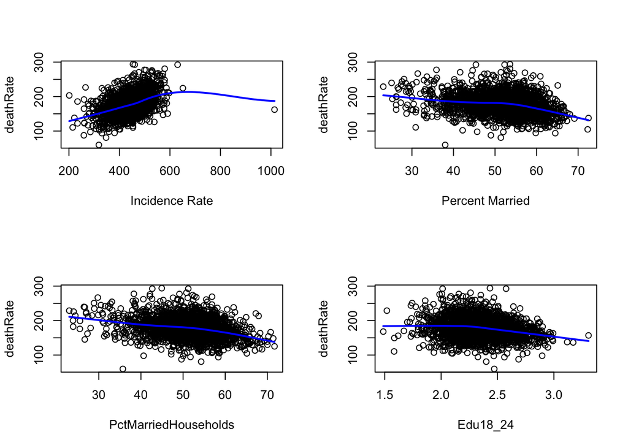

From the scatterplots, the predictor variables show a fairly linear relationship with death Rate.

The fitted lines for PercentMarried, PctMarriedHouseholds and Edu18_24 show an inverse relationship with the response variable.

However,the fitted line for incidence rate indicates that the outliers might have a high influence on the model and therefore we can observe that there is heteroscedasticity.

We need to perform further investigation and tests after fitting a model and we can use spreadLevelPlot() to fix heteroscedasticity.

#Check for Multicollinearity

```r
matrix(cor(cancer2[,c("incidenceRate","PercentMarried","PctMarriedHouseholds","Edu18_24")]), nrow=4, ncol=4)
```

```
##            [,1]        [,2]        [,3]        [,4]
## [1,]  1.0000000 -0.11315444 -0.15354148  0.14164656
## [2,] -0.1131544  1.00000000  0.86964560 -0.03980597
## [3,] -0.1535415  0.86964560  1.00000000 -0.05833673
## [4,]  0.1416466 -0.03980597 -0.05833673  1.00000000
```

PercentMarried and PctMarriedHouseholds are clearly highly correlated. Correlation is 0.87.

We can further check using Pearson Correlation Coefficient test.

#Correlation Test

```r
cor.test(cancer2$PercentMarried,cancer2$PctMarriedHouseholds)
```

```
##
##  Pearson's product-moment correlation
##
## data:  cancer2$PercentMarried and cancer2$PctMarriedHouseholds
## t = 93.811, df = 2836, p-value < 2.2e-16
## alternative hypothesis: true correlation is not equal to 0
## 95 percent confidence interval:
##  0.8603819 0.8783348
## sample estimates:
##       cor
## 0.8696456
```